# datos_liga

```r
# media de goles por partido de cada equipo en su casa
```

[output not shown]

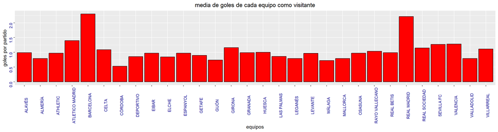

```r
ggplot(train,aes(Away_Team ,Away_Team_Goals_Scored)) +
  geom_bar(position = "dodge", stat = "summary", fun = "mean",
           color = 'black', fill = 'red') +
  labs(title="media de goles de cada equipo como visitante", x="equipos", y="goles por partido") +
  theme(plot.title=element_text(hjust = 0.5), axis.text = element_text(angle = 90, color = "darkblue"))
```

```r
# Los equipos que más goles meten por partido, son los que más temporadas han estado en primera
```

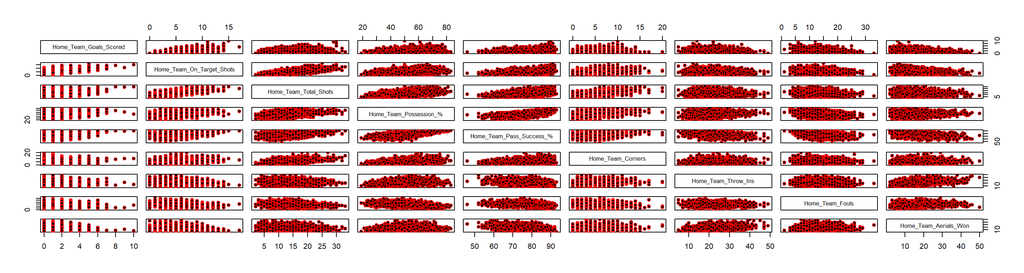

```r
# Correlación de algunas variables
pairs(train %>%
        select(Home_Team_Goals_Scored, Home_Team_On_Target_Shots, Home_Team_Total_Shots, `Home_Team_Possession_%`, `Home_Team_Pass_Success_%`, Home_Team_Corners, Home_Team_Throw_Ins, Home_Team_Fouls, Home_Team_Aerials_Won), pch = 21, bg = "black", col = "red")
```

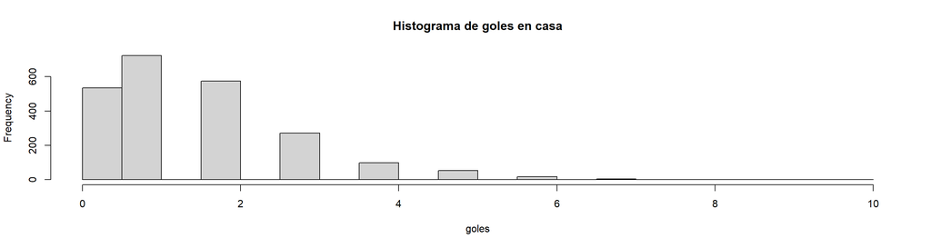

```r
hist(train$Home_Team_Goals_Scored,breaks=15, main = "Histograma de goles en casa",
     xlab = "goles")
```

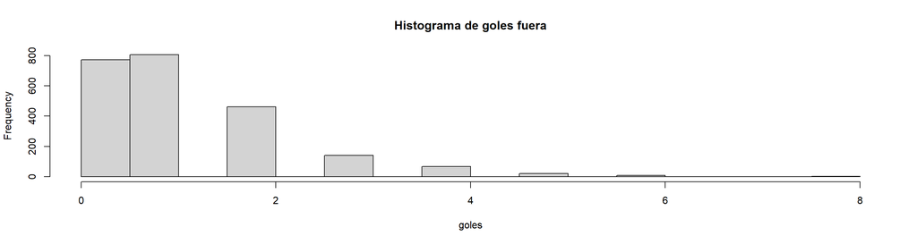

```r
hist(train$Away_Team_Goals_Scored,breaks=15, main = "Histograma de goles fuera",
     xlab = "goles")
```

```r
# Se marcan más goles en casa que fuera
```

```r
lm_fit <- lm(Home_Team_Goals_Scored~.-Home_Team, data=train)
summary(lm_fit)
```

```
##
## Call:
## lm(formula = Home_Team_Goals_Scored ~ . - Home_Team, data = train)
##
## Residuals:
##        Min         1Q     Median         3Q        Max
## -4.046e-13 -1.150e-15 -1.000e-17  1.130e-15  2.845e-14
##
## Coefficients: (12 not defined because of singularities)
##                                 Estimate Std. Error    t value Pr(>|t|)
## (Intercept)                    1.288e-10  5.497e-11  2.343e+00 0.019206 *
## ...1                           1.694e-16  7.182e-17  2.359e+00 0.018424 *
## Away_TeamALMERÍA               2.142e-15  2.533e-15  8.460e-01 0.397875
## Away_TeamATHLETIC             -3.734e-15  1.459e-15 -2.559e+00 0.010550 *
## Away_TeamATLETICO MADRID      -2.088e-15  1.477e-15 -1.414e+00 0.157422
## Away_TeamBARCELONA             1.652e-15  1.677e-15  9.850e-01 0.324792
## Away_TeamCELTA                 1.236e-15  1.482e-15  8.340e-01 0.404219
## Away_TeamCÓRDOBA               3.417e-15  2.531e-15  1.350e+00 0.177204
## Away_TeamDEPORTIVO             7.224e-17  1.613e-15  4.500e-02 0.964274
## Away_TeamEIBAR                -7.201e-16  1.472e-15 -4.890e-01 0.624770
## Away_TeamELCHE                 1.827e-15  2.534e-15  7.210e-01 0.471046
## Away_TeamESPANYOL              3.314e-16  1.448e-15  2.290e-01 0.818993
## Away_TeamGETAFE               -4.272e-16  1.520e-15 -2.810e-01 0.778775
## Away_TeamGIJÓN                 1.125e-15  1.955e-15  5.750e-01 0.565126
## Away_TeamGIRONA                1.990e-15  1.935e-15  1.028e+00 0.303902
## Away_TeamGRANADA               1.595e-15  1.591e-15  1.003e+00 0.316139
## Away_TeamHUESCA                1.007e-15  2.479e-15  4.060e-01 0.684580
## Away_TeamLAS PALMAS            1.777e-15  1.777e-15  1.000e+00 0.317543
## Away_TeamLEGANÉS              -3.707e-15  1.576e-15 -2.352e+00 0.018781 *
## Away_TeamLEVANTE               2.813e-15  1.503e-15  1.871e+00 0.061451 .
## Away_TeamMÁLAGA                6.323e-16  1.606e-15  3.940e-01 0.693873
## Away_TeamMALLORCA              2.071e-15  2.498e-15  8.290e-01 0.407094
## Away_TeamOSASUNA              -4.216e-16  1.932e-15 -2.180e-01 0.827258
## Away_TeamRAYO VALLECANO        1.399e-15  1.762e-15  7.940e-01 0.427454
## Away_TeamREAL BETIS            2.630e-15  1.552e-15  1.694e+00 0.090361 .
## Away_TeamREAL MADRID          -4.300e-15  1.584e-15 -2.715e+00 0.006685 **
## Away_TeamREAL SOCIEDAD         1.293e-15  1.476e-15  8.760e-01 0.381354
## Away_TeamSEVILLA FC            5.347e-16  1.480e-15  3.610e-01 0.717818
## Away_TeamVALENCIA              2.541e-16  1.474e-15  1.720e-01 0.863128
## Away_TeamVALLADOLID            2.389e-15  1.938e-15  1.232e+00 0.217967
```

[output cut: 37 more lines]

```
## total_centros                         NA         NA         NA       NA
## total_d_aereos                        NA         NA         NA       NA
## total_despejes                        NA         NA         NA       NA
## total_faltas                          NA         NA         NA       NA
## total_amarillas                       NA         NA         NA       NA
## total_rojas                           NA         NA         NA       NA
## Home_points                           NA         NA         NA       NA
## Away_points                           NA         NA         NA       NA
## jornada                       -1.659e-15  7.184e-16 -2.309e+00 0.021046 *
## ---
## Signif. codes:  0 '***' 0.001 '**' 0.01 '*' 0.05 '.' 0.1 ' ' 1
##
## Residual standard error: 9.606e-15 on 2216 degrees of freedom
## Multiple R-squared:      1,  Adjusted R-squared:      1
## F-statistic: 7.032e+29 on 63 and 2216 DF,  p-value: < 2.2e-16
```

```r
#regfit_fwd <- leaps::regsubsets(Home_Team_Goals_Scored~., train, method="forward")
#for (metric in c("r2", "adjr2", "Cp", "bic")){plot(regfit_fwd, scale=metric)}
```

```r
prop.table(table(Victorias_casa$Home_Team_Total_Shots > Victorias_casa$Away_Team_Total_Shots))
```

```
##
##     FALSE      TRUE
## 0.3001894 0.6998106
```

```r
#En un 30% de las victorias de casa el equipo de casa tiró menos tiros que el de fuera
```

```r
prop.table(table(Victorias_casa$Home_Team_Blocked_Shots > Victorias_casa$Away_Team_Blocked_Shots))
```

```
##
##     FALSE      TRUE
## 0.5246212 0.4753788
```

```r
#Los tiros bloqueados no influyen mucho en el resultado del partido
```

```r
prop.table(table(Derrotas_casa$Home_Team_Blocked_Shots > Derrotas_casa$Away_Team_Blocked_Shots))
```

```
##
##    FALSE     TRUE
## 0.437788 0.562212
```

```r
#En las derrotas si vemos que el 43% de las veces bloquearon menos
```

# 5 REGRESION

Regrsión con todas las variables

```r
lm_goles <- lm(goles~., data = train)
summary(lm_goles)
```

```
##
## Call:
## lm(formula = goles ~ ., data = train)
##
## Residuals:
##        Min         1Q     Median         3Q        Max
## -3.705e-14 -1.220e-15  1.600e-16  1.320e-15  4.013e-13
##
## Coefficients: (12 not defined because of singularities)
##                                 Estimate Std. Error    t value Pr(>|t|)
## (Intercept)                   -1.118e-10  5.566e-11 -2.008e+00 0.044717 *
## ...1                          -1.467e-16  7.271e-17 -2.017e+00 0.043774 *
## Home_TeamALMERÍA              -8.579e-16  2.549e-15 -3.370e-01 0.736474
## Home_TeamATHLETIC             -1.716e-15  1.473e-15 -1.165e+00 0.244307
## Home_TeamATLETICO MADRID      -2.754e-15  1.491e-15 -1.847e+00 0.064880 .
## Home_TeamBARCELONA            -5.711e-15  1.733e-15 -3.297e+00 0.000994 ***
## Home_TeamCELTA                -1.666e-15  1.518e-15 -1.098e+00 0.272496
## Home_TeamCÓRDOBA               4.057e-16  2.551e-15  1.590e-01 0.873644
## Home_TeamDEPORTIVO             5.838e-16  1.619e-15  3.610e-01 0.718404
## Home_TeamEIBAR                -1.665e-15  1.502e-15 -1.108e+00 0.267937
## Home_TeamELCHE                -9.962e-16  2.556e-15 -3.900e-01 0.696807
## Home_TeamESPANYOL             -2.666e-15  1.459e-15 -1.828e+00 0.067743 .
## Home_TeamGETAFE               -2.996e-15  1.536e-15 -1.951e+00 0.051196 .
## Home_TeamGIJÓN                -5.213e-15  1.982e-15 -2.630e+00 0.008592 **
## Home_TeamGIRONA               -1.591e-15  1.949e-15 -8.160e-01 0.414469
## Home_TeamGRANADA              -1.576e-15  1.600e-15 -9.850e-01 0.324824
## Home_TeamHUESCA                1.578e-15  2.505e-15  6.300e-01 0.528790
## Home_TeamLAS PALMAS           -4.454e-15  1.826e-15 -2.440e+00 0.014786 *
## Home_TeamLEGANÉS              -2.091e-15  1.585e-15 -1.319e+00 0.187311
## Home_TeamLEVANTE              -2.900e-15  1.522e-15 -1.906e+00 0.056801 .
## Home_TeamMÁLAGA                4.217e-15  1.615e-15  2.611e+00 0.009090 **
## Home_TeamMALLORCA             -2.322e-15  2.515e-15 -9.230e-01 0.355917
## Home_TeamOSASUNA               1.127e-16  1.960e-15  5.800e-02 0.954136
## Home_TeamRAYO VALLECANO       -3.944e-15  1.777e-15 -2.220e+00 0.026510 *
## Home_TeamREAL BETIS           -1.805e-15  1.573e-15 -1.148e+00 0.251262
## Home_TeamREAL MADRID          -7.228e-15  1.647e-15 -4.389e+00 1.19e-05 ***
## Home_TeamREAL SOCIEDAD        -7.022e-16  1.502e-15 -4.670e-01 0.640226
## Home_TeamSEVILLA FC           -2.777e-15  1.525e-15 -1.821e+00 0.068763 .
## Home_TeamVALENCIA             -1.836e-15  1.497e-15 -1.227e+00 0.220023
## Home_TeamVALLADOLID            1.418e-15  1.962e-15  7.230e-01 0.469817
```

[output cut: 66 more lines]

```
## total_centros                         NA         NA         NA       NA
## total_d_aereos                        NA         NA         NA       NA
## total_despejes                        NA         NA         NA       NA
## total_faltas                          NA         NA         NA       NA
## total_amarillas                       NA         NA         NA       NA
## total_rojas                           NA         NA         NA       NA
## Home_points                           NA         NA         NA       NA
## Away_points                           NA         NA         NA       NA
## jornada                        1.431e-15  7.273e-16  1.967e+00 0.049324 *
## ---
## Signif. codes:  0 '***' 0.001 '**' 0.01 '*' 0.05 '.' 0.1 ' ' 1
##
## Residual standard error: 9.64e-15 on 2187 degrees of freedom
## Multiple R-squared:      1,  Adjusted R-squared:      1
## F-statistic: 7.742e+29 on 92 and 2187 DF,  p-value: < 2.2e-16
```

```r
lm_disparos <- lm(total_disparos~., data = train)
summary(lm_disparos)
```

```
##
## Call:
## lm(formula = total_disparos ~ ., data = train)
##
## Residuals:
##        Min         1Q     Median         3Q        Max
## -2.777e-13 -1.100e-14  4.800e-15  1.890e-14  6.872e-12
##
## Coefficients: (12 not defined because of singularities)
##                                 Estimate Std. Error    t value Pr(>|t|)
## (Intercept)                   -1.839e-09  8.802e-10 -2.090e+00  0.03676 *
## ...1                          -2.414e-15  1.150e-15 -2.099e+00  0.03591 *
## Home_TeamALMERÍA              -2.628e-14  4.031e-14 -6.520e-01  0.51446
## Home_TeamATHLETIC             -3.593e-15  2.330e-14 -1.540e-01  0.87747
## Home_TeamATLETICO MADRID      -1.082e-14  2.358e-14 -4.590e-01  0.64646
## Home_TeamBARCELONA            -2.727e-14  2.740e-14 -9.950e-01  0.31961
## Home_TeamCELTA                -7.183e-15  2.400e-14 -2.990e-01  0.76476
## Home_TeamCÓRDOBA              -1.060e-15  4.034e-14 -2.600e-02  0.97903
## Home_TeamDEPORTIVO            -4.327e-15  2.560e-14 -1.690e-01  0.86578
## Home_TeamEIBAR                -6.774e-15  2.376e-14 -2.850e-01  0.77557
## Home_TeamELCHE                -1.207e-14  4.043e-14 -2.990e-01  0.76527
## Home_TeamESPANYOL              2.109e-15  2.307e-14  9.100e-02  0.92715
## Home_TeamGETAFE               -1.470e-14  2.428e-14 -6.050e-01  0.54491
## Home_TeamGIJÓN                -1.669e-14  3.134e-14 -5.330e-01  0.59443
## Home_TeamGIRONA                1.076e-15  3.082e-14  3.500e-02  0.97216
## Home_TeamGRANADA              -1.004e-14  2.530e-14 -3.970e-01  0.69164
## Home_TeamHUESCA               -5.042e-15  3.962e-14 -1.270e-01  0.89874
## Home_TeamLAS PALMAS           -8.884e-15  2.887e-14 -3.080e-01  0.75834
## Home_TeamLEGANÉS              -1.046e-14  2.507e-14 -4.170e-01  0.67664
## Home_TeamLEVANTE              -1.636e-14  2.406e-14 -6.800e-01  0.49675
## Home_TeamMÁLAGA                7.782e-14  2.554e-14  3.047e+00  0.00234 **
## Home_TeamMALLORCA             -5.095e-15  3.976e-14 -1.280e-01  0.89806
## Home_TeamOSASUNA              -6.647e-15  3.099e-14 -2.140e-01  0.83021
## Home_TeamRAYO VALLECANO       -9.826e-15  2.809e-14 -3.500e-01  0.72657
## Home_TeamREAL BETIS           -6.906e-15  2.488e-14 -2.780e-01  0.78136
## Home_TeamREAL MADRID          -1.441e-14  2.604e-14 -5.530e-01  0.58013
## Home_TeamREAL SOCIEDAD        -4.491e-15  2.376e-14 -1.890e-01  0.85007
## Home_TeamSEVILLA FC           -8.742e-15  2.412e-14 -3.620e-01  0.71704
## Home_TeamVALENCIA             -6.589e-15  2.367e-14 -2.780e-01  0.78074
## Home_TeamVALLADOLID            5.795e-15  3.102e-14  1.870e-01  0.85183
```

[output cut: 66 more lines]

```
## total_centros                         NA         NA         NA       NA
## total_d_aereos                        NA         NA         NA       NA
## total_despejes                        NA         NA         NA       NA
## total_faltas                          NA         NA         NA       NA
## total_amarillas                       NA         NA         NA       NA
## total_rojas                           NA         NA         NA       NA
## Home_points                           NA         NA         NA       NA
## Away_points                           NA         NA         NA       NA
## jornada                        2.358e-14  1.150e-14  2.050e+00  0.04044 *
## ---
## Signif. codes:  0 '***' 0.001 '**' 0.01 '*' 0.05 '.' 0.1 ' ' 1
##
## Residual standard error: 1.524e-13 on 2187 degrees of freedom
## Multiple R-squared:      1,  Adjusted R-squared:      1
## F-statistic: 3.434e+28 on 92 and 2187 DF,  p-value: < 2.2e-16
```

```r
lm_disparos_bloqueados <- lm(total_disparos_bloqueados~., data = train)
summary(lm_disparos_bloqueados)
```

```
##
## Call:
## lm(formula = total_disparos_bloqueados ~ ., data = train)
##
## Residuals:
##        Min         1Q     Median         3Q        Max
## -1.925e-12 -5.830e-15 -1.470e-15  3.420e-15  3.641e-13
##
## Coefficients: (12 not defined because of singularities)
##                                 Estimate Std. Error    t value Pr(>|t|)
## (Intercept)                    5.527e-10  2.512e-10  2.200e+00  0.02790 *
## ...1                           7.248e-16  3.282e-16  2.209e+00  0.02730 *
## Home_TeamALMERÍA              -4.374e-15  1.150e-14 -3.800e-01  0.70380
## Home_TeamATHLETIC             -1.103e-15  6.650e-15 -1.660e-01  0.86830
## Home_TeamATLETICO MADRID       8.205e-16  6.729e-15  1.220e-01  0.90297
## Home_TeamBARCELONA             4.986e-15  7.819e-15  6.380e-01  0.52378
## Home_TeamCELTA                 2.116e-15  6.850e-15  3.090e-01  0.75742
## Home_TeamCÓRDOBA              -1.502e-15  1.151e-14 -1.300e-01  0.89619
## Home_TeamDEPORTIVO             3.511e-16  7.306e-15  4.800e-02  0.96168
## Home_TeamEIBAR                 2.813e-15  6.780e-15  4.150e-01  0.67823
## Home_TeamELCHE                 4.775e-16  1.154e-14  4.100e-02  0.96700
## Home_TeamESPANYOL              3.052e-16  6.583e-15  4.600e-02  0.96303
## Home_TeamGETAFE                1.352e-15  6.931e-15  1.950e-01  0.84533
## Home_TeamGIJÓN                 2.619e-15  8.946e-15  2.930e-01  0.76969
## Home_TeamGIRONA               -2.406e-16  8.796e-15 -2.700e-02  0.97818
## Home_TeamGRANADA               1.697e-15  7.221e-15  2.350e-01  0.81418
## Home_TeamHUESCA               -8.261e-17  1.131e-14 -7.000e-03  0.99417
## Home_TeamLAS PALMAS           -4.316e-16  8.240e-15 -5.200e-02  0.95823
## Home_TeamLEGANÉS               6.674e-15  7.155e-15  9.330e-01  0.35102
## Home_TeamLEVANTE               3.053e-15  6.868e-15  4.450e-01  0.65666
## Home_TeamMÁLAGA               -2.275e-14  7.290e-15 -3.121e+00  0.00182 **
## Home_TeamMALLORCA             -3.584e-16  1.135e-14 -3.200e-02  0.97481
## Home_TeamOSASUNA               8.557e-16  8.846e-15  9.700e-02  0.92294
## Home_TeamRAYO VALLECANO        3.417e-15  8.018e-15  4.260e-01  0.67002
## Home_TeamREAL BETIS            4.033e-15  7.100e-15  5.680e-01  0.57005
## Home_TeamREAL MADRID           7.547e-15  7.432e-15  1.015e+00  0.31003
## Home_TeamREAL SOCIEDAD         1.414e-15  6.780e-15  2.090e-01  0.83485
## Home_TeamSEVILLA FC            2.508e-15  6.883e-15  3.640e-01  0.71558
## Home_TeamVALENCIA             -1.447e-15  6.755e-15 -2.140e-01  0.83042
## Home_TeamVALLADOLID           -1.889e-15  8.853e-15 -2.130e-01  0.83105
```

[output cut: 66 more lines]

```
## total_centros                         NA         NA         NA       NA
## total_d_aereos                        NA         NA         NA       NA
## total_despejes                        NA         NA         NA       NA
## total_faltas                          NA         NA         NA       NA
## total_amarillas                       NA         NA         NA       NA
## total_rojas                           NA         NA         NA       NA
## Home_points                           NA         NA         NA       NA
## Away_points                           NA         NA         NA       NA
## jornada                       -7.111e-15  3.283e-15 -2.166e+00  0.03040 *
## ---
## Signif. codes:  0 '***' 0.001 '**' 0.01 '*' 0.05 '.' 0.1 ' ' 1
##
## Residual standard error: 4.351e-14 on 2187 degrees of freedom
## Multiple R-squared:      1,  Adjusted R-squared:      1
## F-statistic: 8.906e+28 on 92 and 2187 DF,  p-value: < 2.2e-16
```

```r
lm_corners <- lm(total_corners~., data = train)
summary(lm_corners)
```

```
##
## Call:
## lm(formula = total_corners ~ ., data = train)
##
## Residuals:
##        Min         1Q     Median         3Q        Max
## -3.204e-12 -9.000e-15 -2.000e-15  5.100e-15  2.908e-13
##
## Coefficients: (12 not defined because of singularities)
##                                 Estimate Std. Error    t value Pr(>|t|)
## (Intercept)                    9.502e-10  4.124e-10  2.304e+00  0.02133 *
## ...1                           1.248e-15  5.388e-16  2.316e+00  0.02067 *
## Home_TeamALMERÍA              -1.401e-15  1.889e-14 -7.400e-02  0.94086
## Home_TeamATHLETIC              9.544e-16  1.092e-14  8.700e-02  0.93035
## Home_TeamATLETICO MADRID       2.268e-15  1.105e-14  2.050e-01  0.83738
## Home_TeamBARCELONA             9.317e-15  1.284e-14  7.260e-01  0.46807
## Home_TeamCELTA                 3.894e-15  1.125e-14  3.460e-01  0.72919
## Home_TeamCÓRDOBA               7.328e-16  1.890e-14  3.900e-02  0.96908
## Home_TeamDEPORTIVO            -1.822e-16  1.199e-14 -1.500e-02  0.98788
## Home_TeamEIBAR                 3.054e-15  1.113e-14  2.740e-01  0.78383
## Home_TeamELCHE                 4.345e-15  1.894e-14  2.290e-01  0.81862
## Home_TeamESPANYOL              9.263e-16  1.081e-14  8.600e-02  0.93171
## Home_TeamGETAFE                8.083e-15  1.138e-14  7.100e-01  0.47754
## Home_TeamGIJÓN                 4.516e-15  1.469e-14  3.070e-01  0.75851
## Home_TeamGIRONA               -3.106e-15  1.444e-14 -2.150e-01  0.82972
## Home_TeamGRANADA               4.445e-15  1.185e-14  3.750e-01  0.70776
## Home_TeamHUESCA               -2.815e-15  1.856e-14 -1.520e-01  0.87947
## Home_TeamLAS PALMAS           -2.163e-16  1.353e-14 -1.600e-02  0.98725
## Home_TeamLEGANÉS               2.198e-15  1.175e-14  1.870e-01  0.85162
## Home_TeamLEVANTE               5.423e-15  1.128e-14  4.810e-01  0.63058
## Home_TeamMÁLAGA               -3.689e-14  1.197e-14 -3.082e+00  0.00208 **
## Home_TeamMALLORCA              7.586e-15  1.863e-14  4.070e-01  0.68395
## Home_TeamOSASUNA               4.638e-16  1.452e-14  3.200e-02  0.97453
## Home_TeamRAYO VALLECANO        5.441e-15  1.316e-14  4.130e-01  0.67941
## Home_TeamREAL BETIS            3.837e-15  1.166e-14  3.290e-01  0.74210
## Home_TeamREAL MADRID           6.387e-15  1.220e-14  5.230e-01  0.60072
## Home_TeamREAL SOCIEDAD         3.309e-15  1.113e-14  2.970e-01  0.76627
## Home_TeamSEVILLA FC            2.082e-15  1.130e-14  1.840e-01  0.85383
## Home_TeamVALENCIA              2.511e-16  1.109e-14  2.300e-02  0.98194
## Home_TeamVALLADOLID            5.145e-17  1.453e-14  4.000e-03  0.99718
```

[output cut: 66 more lines]

```
## total_centros                         NA         NA         NA       NA
## total_d_aereos                        NA         NA         NA       NA
## total_despejes                        NA         NA         NA       NA
## total_faltas                          NA         NA         NA       NA
## total_amarillas                       NA         NA         NA       NA
## total_rojas                           NA         NA         NA       NA
## Home_points                           NA         NA         NA       NA
## Away_points                           NA         NA         NA       NA
## jornada                       -1.220e-14  5.390e-15 -2.264e+00  0.02365 *
## ---
## Signif. codes:  0 '***' 0.001 '**' 0.01 '*' 0.05 '.' 0.1 ' ' 1
##
## Residual standard error: 7.143e-14 on 2187 degrees of freedom
## Multiple R-squared:      1,  Adjusted R-squared:      1
## F-statistic: 5.542e+28 on 92 and 2187 DF,  p-value: < 2.2e-16
```

```r
lm_centros <- lm(total_centros~., data = train)
summary(lm_centros)
```

```
##
## Call:
## lm(formula = total_centros ~ ., data = train)
##
## Residuals:
##        Min         1Q     Median         3Q        Max
## -4.585e-12 -1.360e-14 -3.100e-15  8.100e-15  4.871e-13
##
## Coefficients: (12 not defined because of singularities)
##                                 Estimate Std. Error    t value Pr(>|t|)
## (Intercept)                    1.497e-09  5.969e-10  2.508e+00  0.01220 *
## ...1                           1.964e-15  7.798e-16  2.519e+00  0.01185 *
## Home_TeamALMERÍA               3.253e-14  2.734e-14  1.190e+00  0.23420
## Home_TeamATHLETIC              3.444e-14  1.580e-14  2.179e+00  0.02941 *
## Home_TeamATLETICO MADRID       2.640e-14  1.599e-14  1.651e+00  0.09888 .
## Home_TeamBARCELONA             3.700e-14  1.858e-14  1.991e+00  0.04656 *
## Home_TeamCELTA                 3.063e-14  1.628e-14  1.882e+00  0.05999 .
## Home_TeamCÓRDOBA               4.672e-14  2.736e-14  1.708e+00  0.08778 .
## Home_TeamDEPORTIVO             2.726e-14  1.736e-14  1.570e+00  0.11646
## Home_TeamEIBAR                 3.341e-14  1.611e-14  2.074e+00  0.03820 *
## Home_TeamELCHE                 1.642e-14  2.742e-14  5.990e-01  0.54919
## Home_TeamESPANYOL              2.007e-14  1.564e-14  1.283e+00  0.19961
## Home_TeamGETAFE                3.796e-14  1.647e-14  2.305e+00  0.02125 *
## Home_TeamGIJÓN                 2.845e-14  2.126e-14  1.338e+00  0.18091
## Home_TeamGIRONA                1.521e-14  2.090e-14  7.280e-01  0.46684
## Home_TeamGRANADA               6.072e-15  1.716e-14  3.540e-01  0.72343
## Home_TeamHUESCA                1.936e-14  2.687e-14  7.200e-01  0.47130
## Home_TeamLAS PALMAS            2.150e-14  1.958e-14  1.098e+00  0.27229
## Home_TeamLEGANÉS               3.990e-14  1.700e-14  2.347e+00  0.01902 *
## Home_TeamLEVANTE               3.005e-14  1.632e-14  1.842e+00  0.06568 .
## Home_TeamMÁLAGA               -3.739e-14  1.732e-14 -2.158e+00  0.03101 *
## Home_TeamMALLORCA              1.508e-14  2.697e-14  5.590e-01  0.57608
## Home_TeamOSASUNA               1.821e-14  2.102e-14  8.660e-01  0.38654
## Home_TeamRAYO VALLECANO        5.337e-14  1.905e-14  2.801e+00  0.00514 **
## Home_TeamREAL BETIS            2.152e-14  1.687e-14  1.276e+00  0.20224
## Home_TeamREAL MADRID           3.116e-14  1.766e-14  1.764e+00  0.07781 .
## Home_TeamREAL SOCIEDAD         2.792e-14  1.611e-14  1.733e+00  0.08327 .
## Home_TeamSEVILLA FC            2.277e-14  1.636e-14  1.392e+00  0.16404
## Home_TeamVALENCIA              1.623e-14  1.605e-14  1.011e+00  0.31210
## Home_TeamVALLADOLID            1.554e-14  2.104e-14  7.390e-01  0.46010
```

[output cut: 66 more lines]

```
## total_corners                         NA         NA         NA       NA
## total_d_aereos                        NA         NA         NA       NA
## total_despejes                        NA         NA         NA       NA
## total_faltas                          NA         NA         NA       NA
## total_amarillas                       NA         NA         NA       NA
## total_rojas                           NA         NA         NA       NA
## Home_points                           NA         NA         NA       NA
## Away_points                           NA         NA         NA       NA
## jornada                       -1.925e-14  7.800e-15 -2.468e+00  0.01367 *
## ---
## Signif. codes:  0 '***' 0.001 '**' 0.01 '*' 0.05 '.' 0.1 ' ' 1
##
## Residual standard error: 1.034e-13 on 2187 degrees of freedom
## Multiple R-squared:      1,  Adjusted R-squared:      1
## F-statistic: 2.604e+29 on 92 and 2187 DF,  p-value: < 2.2e-16
```

```r
lm_d_aereos <- lm(total_d_aereos~., data = train)
summary(lm_d_aereos)
```

```
##
## Call:
## lm(formula = total_d_aereos ~ ., data = train)
##
## Residuals:
##        Min         1Q     Median         3Q        Max
## -1.417e-12 -6.440e-15 -6.500e-16  5.600e-15  4.655e-13
##
## Coefficients: (12 not defined because of singularities)
##                                 Estimate Std. Error    t value Pr(>|t|)
## (Intercept)                    3.225e-10  2.190e-10  1.472e+00 0.141044
## ...1                           4.292e-16  2.861e-16  1.500e+00 0.133761
## Home_TeamALMERÍA              -4.211e-15  1.003e-14 -4.200e-01 0.674666
## Home_TeamATHLETIC              1.097e-14  5.798e-15  1.892e+00 0.058674 .
## Home_TeamATLETICO MADRID       6.549e-15  5.867e-15  1.116e+00 0.264419
## Home_TeamBARCELONA            -5.492e-14  6.817e-15 -8.055e+00 1.29e-15 ***
## Home_TeamCELTA                 1.591e-15  5.972e-15  2.660e-01 0.789936
## Home_TeamCÓRDOBA               1.929e-14  1.004e-14  1.922e+00 0.054758 .
## Home_TeamDEPORTIVO             1.122e-15  6.369e-15  1.760e-01 0.860246
## Home_TeamEIBAR                -2.061e-14  5.911e-15 -3.486e+00 0.000500 ***
## Home_TeamELCHE                 2.482e-15  1.006e-14  2.470e-01 0.805121
## Home_TeamESPANYOL              1.007e-14  5.740e-15  1.754e+00 0.079590 .
## Home_TeamGETAFE                4.009e-15  6.043e-15  6.640e-01 0.507067
## Home_TeamGIJÓN                -1.130e-14  7.799e-15 -1.449e+00 0.147596
## Home_TeamGIRONA                1.369e-15  7.669e-15  1.780e-01 0.858389
## Home_TeamGRANADA              -3.524e-15  6.295e-15 -5.600e-01 0.575700
## Home_TeamHUESCA               -1.076e-14  9.858e-15 -1.092e+00 0.275110
## Home_TeamLAS PALMAS            1.593e-15  7.184e-15  2.220e-01 0.824522
## Home_TeamLEGANÉS               1.303e-14  6.238e-15  2.089e+00 0.036847 *
## Home_TeamLEVANTE               4.753e-15  5.988e-15  7.940e-01 0.427388
## Home_TeamMÁLAGA               -1.929e-14  6.356e-15 -3.036e+00 0.002427 **
## Home_TeamMALLORCA              1.511e-14  9.895e-15  1.527e+00 0.126869
## Home_TeamOSASUNA              -2.755e-14  7.713e-15 -3.572e+00 0.000362 ***
## Home_TeamRAYO VALLECANO       -3.378e-15  6.991e-15 -4.830e-01 0.629039
## Home_TeamREAL BETIS           -1.096e-14  6.191e-15 -1.771e+00 0.076704 .
## Home_TeamREAL MADRID           1.505e-14  6.480e-15  2.322e+00 0.020335 *
## Home_TeamREAL SOCIEDAD         8.537e-15  5.911e-15  1.444e+00 0.148848
## Home_TeamSEVILLA FC           -7.033e-15  6.001e-15 -1.172e+00 0.241374
## Home_TeamVALENCIA             -1.349e-15  5.889e-15 -2.290e-01 0.818837
## Home_TeamVALLADOLID            4.132e-15  7.718e-15  5.350e-01 0.592484
```

[output cut: 66 more lines]

```
## total_corners                         NA         NA         NA       NA
## total_centros                         NA         NA         NA       NA
## total_despejes                        NA         NA         NA       NA
## total_faltas                          NA         NA         NA       NA
## total_amarillas                       NA         NA         NA       NA
## total_rojas                           NA         NA         NA       NA
## Home_points                           NA         NA         NA       NA
## Away_points                           NA         NA         NA       NA
## jornada                       -4.110e-15  2.862e-15 -1.436e+00 0.151118
## ---
## Signif. codes:  0 '***' 0.001 '**' 0.01 '*' 0.05 '.' 0.1 ' ' 1
##
## Residual standard error: 3.793e-14 on 2187 degrees of freedom
## Multiple R-squared:      1,  Adjusted R-squared:      1
## F-statistic: 3.048e+30 on 92 and 2187 DF,  p-value: < 2.2e-16
```

```r
lm_despejes <- lm(total_despejes~., data = train)
summary(lm_despejes)
```

```
##
## Call:
## lm(formula = total_despejes ~ ., data = train)
##
## Residuals:
##        Min         1Q     Median         3Q        Max
## -1.410e-12 -6.400e-15 -5.200e-16  5.700e-15  2.743e-13
##
## Coefficients: (12 not defined because of singularities)
##                                 Estimate Std. Error    t value Pr(>|t|)
## (Intercept)                    4.220e-10  2.322e-10  1.817e+00 0.069312 .
## ...1                           5.416e-16  3.033e-16  1.785e+00 0.074352 .
## Home_TeamALMERÍA               2.939e-14  1.063e-14  2.764e+00 0.005754 **
## Home_TeamATHLETIC              3.383e-14  6.147e-15  5.504e+00 4.15e-08 ***
## Home_TeamATLETICO MADRID       2.724e-14  6.220e-15  4.379e+00 1.25e-05 ***
## Home_TeamBARCELONA             1.618e-14  7.228e-15  2.238e+00 0.025295 *
## Home_TeamCELTA                 3.177e-14  6.332e-15  5.018e+00 5.64e-07 ***
## Home_TeamCÓRDOBA               1.773e-14  1.064e-14  1.666e+00 0.095891 .
## Home_TeamDEPORTIVO             3.059e-14  6.753e-15  4.530e+00 6.22e-06 ***
## Home_TeamEIBAR                 3.080e-14  6.267e-15  4.915e+00 9.52e-07 ***
## Home_TeamELCHE                 1.326e-14  1.066e-14  1.243e+00 0.213984
## Home_TeamESPANYOL              1.179e-14  6.085e-15  1.938e+00 0.052783 .
## Home_TeamGETAFE                6.110e-17  6.406e-15  1.000e-02 0.992391
## Home_TeamGIJÓN                 2.265e-14  8.269e-15  2.740e+00 0.006199 **
## Home_TeamGIRONA                2.126e-14  8.131e-15  2.615e+00 0.008984 **
## Home_TeamGRANADA               1.168e-14  6.674e-15  1.751e+00 0.080156 .
## Home_TeamHUESCA                3.320e-14  1.045e-14  3.177e+00 0.001511 **
## Home_TeamLAS PALMAS            3.083e-14  7.617e-15  4.048e+00 5.35e-05 ***
## Home_TeamLEGANÉS               5.635e-15  6.614e-15  8.520e-01 0.394296
## Home_TeamLEVANTE               1.786e-14  6.348e-15  2.813e+00 0.004945 **
## Home_TeamMÁLAGA                9.482e-16  6.738e-15  1.410e-01 0.888108
## Home_TeamMALLORCA              9.113e-15  1.049e-14  8.690e-01 0.385113
## Home_TeamOSASUNA               2.026e-14  8.177e-15  2.478e+00 0.013296 *
## Home_TeamRAYO VALLECANO        3.490e-14  7.412e-15  4.709e+00 2.64e-06 ***
## Home_TeamREAL BETIS            2.829e-14  6.563e-15  4.311e+00 1.70e-05 ***
## Home_TeamREAL MADRID           3.470e-14  6.870e-15  5.051e+00 4.75e-07 ***
## Home_TeamREAL SOCIEDAD         3.580e-14  6.267e-15  5.712e+00 1.27e-08 ***
## Home_TeamSEVILLA FC            5.035e-14  6.363e-15  7.913e+00 3.96e-15 ***
## Home_TeamVALENCIA              2.470e-14  6.244e-15  3.956e+00 7.88e-05 ***
## Home_TeamVALLADOLID            1.271e-14  8.183e-15  1.553e+00 0.120590
```

[output cut: 66 more lines]

```
## total_corners                         NA         NA         NA       NA
## total_centros                         NA         NA         NA       NA
## total_d_aereos                        NA         NA         NA       NA
## total_faltas                          NA         NA         NA       NA
## total_amarillas                       NA         NA         NA       NA
## total_rojas                           NA         NA         NA       NA
## Home_points                           NA         NA         NA       NA
## Away_points                           NA         NA         NA       NA
## jornada                       -5.357e-15  3.034e-15 -1.765e+00 0.077635 .
## ---
## Signif. codes:  0 '***' 0.001 '**' 0.01 '*' 0.05 '.' 0.1 ' ' 1
##
## Residual standard error: 4.022e-14 on 2187 degrees of freedom
## Multiple R-squared:      1,  Adjusted R-squared:      1
## F-statistic: 1.952e+30 on 92 and 2187 DF,  p-value: < 2.2e-16
```

```r
lm_faltas <- lm(total_faltas~., data = train)
summary(lm_faltas)
```

```
##
## Call:
## lm(formula = total_faltas ~ ., data = train)
##
## Residuals:
##        Min         1Q     Median         3Q        Max
## -8.318e-13 -1.190e-14  5.500e-15  2.220e-14  7.834e-12
##
## Coefficients: (12 not defined because of singularities)
##                                 Estimate Std. Error    t value Pr(>|t|)
## (Intercept)                   -1.947e-09  1.008e-09 -1.931e+00  0.05363 .
## ...1                          -2.557e-15  1.317e-15 -1.942e+00  0.05232 .
## Home_TeamALMERÍA              -3.211e-14  4.617e-14 -6.950e-01  0.48686
## Home_TeamATHLETIC             -1.391e-14  2.669e-14 -5.210e-01  0.60227
## Home_TeamATLETICO MADRID      -1.361e-14  2.701e-14 -5.040e-01  0.61435
## Home_TeamBARCELONA            -3.877e-14  3.138e-14 -1.235e+00  0.21678
## Home_TeamCELTA                -2.137e-14  2.749e-14 -7.770e-01  0.43711
## Home_TeamCÓRDOBA              -1.669e-14  4.620e-14 -3.610e-01  0.71788
## Home_TeamDEPORTIVO            -1.478e-14  2.932e-14 -5.040e-01  0.61426
## Home_TeamEIBAR                -1.956e-14  2.721e-14 -7.190e-01  0.47243
## Home_TeamELCHE                -1.165e-14  4.631e-14 -2.520e-01  0.80131
## Home_TeamESPANYOL             -3.314e-15  2.642e-14 -1.250e-01  0.90019
## Home_TeamGETAFE               -2.167e-14  2.782e-14 -7.790e-01  0.43593
## Home_TeamGIJÓN                -2.425e-14  3.590e-14 -6.750e-01  0.49954
## Home_TeamGIRONA                7.219e-15  3.530e-14  2.040e-01  0.83799
## Home_TeamGRANADA              -1.259e-14  2.898e-14 -4.340e-01  0.66407
## Home_TeamHUESCA                8.204e-15  4.538e-14  1.810e-01  0.85656
## Home_TeamLAS PALMAS           -1.363e-14  3.307e-14 -4.120e-01  0.68030
## Home_TeamLEGANÉS              -1.051e-14  2.872e-14 -3.660e-01  0.71440
## Home_TeamLEVANTE              -2.566e-14  2.756e-14 -9.310e-01  0.35207
## Home_TeamMÁLAGA                8.647e-14  2.926e-14  2.956e+00  0.00315 **
## Home_TeamMALLORCA             -9.774e-15  4.555e-14 -2.150e-01  0.83010
## Home_TeamOSASUNA              -1.683e-14  3.550e-14 -4.740e-01  0.63555
## Home_TeamRAYO VALLECANO       -2.108e-14  3.218e-14 -6.550e-01  0.51247
## Home_TeamREAL BETIS           -1.685e-14  2.850e-14 -5.910e-01  0.55439
## Home_TeamREAL MADRID          -2.706e-14  2.983e-14 -9.070e-01  0.36444
## Home_TeamREAL SOCIEDAD        -1.534e-14  2.721e-14 -5.640e-01  0.57295
## Home_TeamSEVILLA FC           -3.415e-15  2.763e-14 -1.240e-01  0.90163
## Home_TeamVALENCIA             -7.522e-15  2.711e-14 -2.770e-01  0.78147
## Home_TeamVALLADOLID           -7.603e-15  3.553e-14 -2.140e-01  0.83057
```

[output cut: 66 more lines]

```
## total_corners                         NA         NA         NA       NA
## total_centros                         NA         NA         NA       NA
## total_d_aereos                        NA         NA         NA       NA
## total_despejes                        NA         NA         NA       NA
## total_amarillas                       NA         NA         NA       NA
## total_rojas                           NA         NA         NA       NA
## Home_points                           NA         NA         NA       NA
## Away_points                           NA         NA         NA       NA
## jornada                        2.495e-14  1.317e-14  1.894e+00  0.05841 .
## ---
## Signif. codes:  0 '***' 0.001 '**' 0.01 '*' 0.05 '.' 0.1 ' ' 1
##
## Residual standard error: 1.746e-13 on 2187 degrees of freedom
## Multiple R-squared:      1,  Adjusted R-squared:      1
## F-statistic: 2.829e+28 on 92 and 2187 DF,  p-value: < 2.2e-16
```

```r
lm_amarillas <- lm(total_amarillas~., data = train)
summary(lm_amarillas)
```

```
##
## Call:
## lm(formula = total_amarillas ~ ., data = train)
##
## Residuals:
##        Min         1Q     Median         3Q        Max
## -3.375e-12 -9.400e-15 -2.100e-15  5.700e-15  1.370e-13
##
## Coefficients: (12 not defined because of singularities)
##                                 Estimate Std. Error    t value Pr(>|t|)
## (Intercept)                    9.790e-10  4.323e-10  2.265e+00  0.02363 *
## ...1                           1.285e-15  5.648e-16  2.276e+00  0.02294 *
## Home_TeamALMERÍA               2.465e-15  1.980e-14  1.250e-01  0.90091
## Home_TeamATHLETIC              6.155e-16  1.144e-14  5.400e-02  0.95711
## Home_TeamATLETICO MADRID       3.779e-15  1.158e-14  3.260e-01  0.74419
## Home_TeamBARCELONA             6.041e-15  1.346e-14  4.490e-01  0.65350
## Home_TeamCELTA                 4.714e-15  1.179e-14  4.000e-01  0.68924
## Home_TeamCÓRDOBA               1.294e-15  1.981e-14  6.500e-02  0.94791
## Home_TeamDEPORTIVO             2.178e-15  1.257e-14  1.730e-01  0.86250
## Home_TeamEIBAR                -2.544e-16  1.167e-14 -2.200e-02  0.98261
## Home_TeamELCHE                 7.778e-15  1.986e-14  3.920e-01  0.69529
## Home_TeamESPANYOL              1.489e-15  1.133e-14  1.310e-01  0.89545
## Home_TeamGETAFE                4.777e-15  1.193e-14  4.010e-01  0.68879
## Home_TeamGIJÓN                 1.010e-14  1.539e-14  6.560e-01  0.51179
## Home_TeamGIRONA               -1.321e-15  1.514e-14 -8.700e-02  0.93045
## Home_TeamGRANADA               3.359e-15  1.243e-14  2.700e-01  0.78696
## Home_TeamHUESCA               -5.856e-15  1.946e-14 -3.010e-01  0.76347
## Home_TeamLAS PALMAS            2.682e-15  1.418e-14  1.890e-01  0.84998
## Home_TeamLEGANÉS               3.795e-15  1.231e-14  3.080e-01  0.75797
## Home_TeamLEVANTE               5.451e-15  1.182e-14  4.610e-01  0.64469
## Home_TeamMÁLAGA               -3.852e-14  1.254e-14 -3.071e+00  0.00216 **
## Home_TeamMALLORCA              1.063e-15  1.953e-14  5.400e-02  0.95660
## Home_TeamOSASUNA              -6.308e-16  1.522e-14 -4.100e-02  0.96695
## Home_TeamRAYO VALLECANO        4.713e-15  1.380e-14  3.420e-01  0.73272
## Home_TeamREAL BETIS            6.363e-15  1.222e-14  5.210e-01  0.60262
## Home_TeamREAL MADRID           1.215e-14  1.279e-14  9.500e-01  0.34211
## Home_TeamREAL SOCIEDAD         5.935e-16  1.167e-14  5.100e-02  0.95944
## Home_TeamSEVILLA FC            3.621e-15  1.185e-14  3.060e-01  0.75987
## Home_TeamVALENCIA              4.316e-15  1.162e-14  3.710e-01  0.71044
## Home_TeamVALLADOLID           -3.004e-15  1.523e-14 -1.970e-01  0.84372
```

[output cut: 66 more lines]

```
## total_corners                         NA         NA         NA       NA
## total_centros                         NA         NA         NA       NA
## total_d_aereos                        NA         NA         NA       NA
## total_despejes                        NA         NA         NA       NA
## total_faltas                          NA         NA         NA       NA
## total_rojas                           NA         NA         NA       NA
## Home_points                           NA         NA         NA       NA
## Away_points                           NA         NA         NA       NA
## jornada                       -1.257e-14  5.649e-15 -2.224e+00  0.02623 *
## ---
## Signif. codes:  0 '***' 0.001 '**' 0.01 '*' 0.05 '.' 0.1 ' ' 1
##
## Residual standard error: 7.487e-14 on 2187 degrees of freedom
## Multiple R-squared:      1,  Adjusted R-squared:      1
## F-statistic: 2.292e+28 on 92 and 2187 DF,  p-value: < 2.2e-16
```

```r
lm_rojas <- lm(total_rojas~., data = train)
summary(lm_rojas)
```

```
##
## Call:
## lm(formula = total_rojas ~ ., data = train)
##
## Residuals:
##        Min         1Q     Median         3Q        Max
## -3.856e-14 -1.230e-16 -1.800e-17  9.400e-17  5.233e-15
##
## Coefficients: (12 not defined because of singularities)
##                                 Estimate Std. Error    t value Pr(>|t|)
## (Intercept)                    1.109e-11  5.139e-12  2.158e+00  0.03101 *
## ...1                           1.459e-17  6.713e-18  2.173e+00  0.02991 *
## Home_TeamALMERÍA               8.082e-17  2.353e-16  3.430e-01  0.73129
## Home_TeamATHLETIC             -1.785e-17  1.360e-16 -1.310e-01  0.89564
## Home_TeamATLETICO MADRID       2.042e-16  1.377e-16  1.483e+00  0.13811
## Home_TeamBARCELONA             5.020e-16  1.600e-16  3.138e+00  0.00172 **
## Home_TeamCELTA                -2.982e-17  1.401e-16 -2.130e-01  0.83151
## Home_TeamCÓRDOBA               9.929e-17  2.355e-16  4.220e-01  0.67336
## Home_TeamDEPORTIVO            -1.149e-16  1.494e-16 -7.690e-01  0.44225
## Home_TeamEIBAR                -2.527e-16  1.387e-16 -1.822e+00  0.06855 .
## Home_TeamELCHE                -1.037e-16  2.360e-16 -4.390e-01  0.66051
## Home_TeamESPANYOL             -6.293e-17  1.347e-16 -4.670e-01  0.64034
## Home_TeamGETAFE               -6.033e-17  1.418e-16 -4.250e-01  0.67051
## Home_TeamGIJÓN                -2.240e-17  1.830e-16 -1.220e-01  0.90257
## Home_TeamGIRONA               -9.116e-17  1.799e-16 -5.070e-01  0.61248
## Home_TeamGRANADA              -1.467e-16  1.477e-16 -9.930e-01  0.32086
## Home_TeamHUESCA               -1.402e-16  2.313e-16 -6.060e-01  0.54460
## Home_TeamLAS PALMAS            1.328e-17  1.686e-16  7.900e-02  0.93720
## Home_TeamLEGANÉS               4.360e-17  1.464e-16  2.980e-01  0.76582
## Home_TeamLEVANTE              -1.134e-16  1.405e-16 -8.070e-01  0.41981
## Home_TeamMÁLAGA               -4.798e-16  1.491e-16 -3.217e+00  0.00131 **
## Home_TeamMALLORCA             -4.796e-16  2.322e-16 -2.066e+00  0.03898 *
## Home_TeamOSASUNA              -1.329e-16  1.810e-16 -7.340e-01  0.46274
## Home_TeamRAYO VALLECANO       -1.158e-16  1.640e-16 -7.060e-01  0.48018
## Home_TeamREAL BETIS            2.193e-17  1.453e-16  1.510e-01  0.88002
## Home_TeamREAL MADRID           1.220e-16  1.520e-16  8.020e-01  0.42253
## Home_TeamREAL SOCIEDAD         5.727e-17  1.387e-16  4.130e-01  0.67969
## Home_TeamSEVILLA FC            3.920e-17  1.408e-16  2.780e-01  0.78074
## Home_TeamVALENCIA             -9.378e-18  1.382e-16 -6.800e-02  0.94590
## Home_TeamVALLADOLID           -3.522e-16  1.811e-16 -1.945e+00  0.05192 .
```

[output cut: 66 more lines]

```
## total_corners                         NA         NA         NA       NA
## total_centros                         NA         NA         NA       NA
## total_d_aereos                        NA         NA         NA       NA
## total_despejes                        NA         NA         NA       NA
## total_faltas                          NA         NA         NA       NA
## total_amarillas                       NA         NA         NA       NA
## Home_points                           NA         NA         NA       NA
## Away_points                           NA         NA         NA       NA
## jornada                       -1.431e-16  6.715e-17 -2.131e+00  0.03320 *
## ---
## Signif. codes:  0 '***' 0.001 '**' 0.01 '*' 0.05 '.' 0.1 ' ' 1
##
## Residual standard error: 8.9e-16 on 2187 degrees of freedom
## Multiple R-squared:      1,  Adjusted R-squared:      1
## F-statistic: 3.303e+30 on 92 and 2187 DF,  p-value: < 2.2e-16
```

# CONCLUSIONES Hay muchas variables que no afectan al resultado de un partido.  
Los equipos locales ganan más.

Hay dos equipos que sobresalen (Madrid y Barsa)  
Hay un grupo de equipos “buenos” (nunca han descendido, meten más goles…)

De cara al futuro:  
Cuanto se parecen dos partidos?  
Clusterizar equipos en buenos, medios y malos.  
Incluir las rachas de victorias, dorrotas y empates.  
Calcular los puntos que suma cada equipo por partido en función de ser local o visitante, del “nivel” del rival, etc.  
Predecir el número de goles que va a marcar cada equipo en un partido, en vez de victoria/derrota/empate.